# Planejamento e Análise de Experimentos Agrícolas

Dr. José Tiago B. Chagas

Departamento de Genética  
Escola Superior de Agricultura Luiz de Queiroz  
Universidade de São Paulo

19/01/2026

## Background

[figure not shown]

*Agronomist (**UFCA**→ 2018)*

*Msc. in Genetics and plant breeding (**UENF**→2020)*

*Dsc. in Genetics and breeding (**UFV**→ 2024)*

*Postdoctoral research scholar (**UFV**→2024-2025); (**ESALQ/USP**→Current)*

# Introduction to Agricultural Experimental

## Scientific method

[figure not shown]

*Source: [Indeed.com - Scientific Method Steps](https://www.indeed.com/career-advice/career-development/scientific-method-steps)*

## Gregor Mendel (1822-1884)

[figure not shown]

Austrian monk carried out experiments (1854-1863)

- Segregation (genetic factors segregate during the formation of gametes)
- Independent assortment laws (Traits often segregate independently of the other)
- Dominance (Dominant and recessive alleles)

## Mendel Experiments

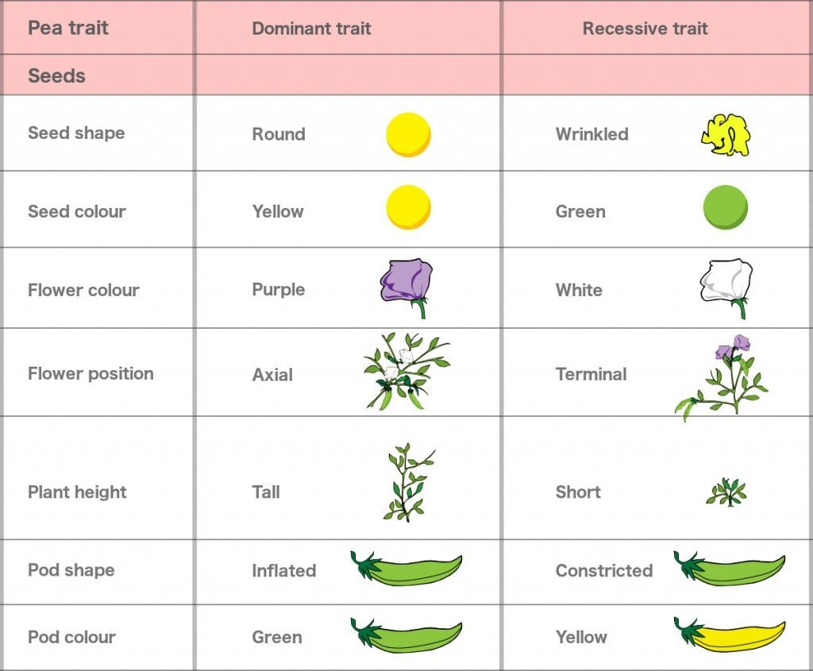

*Source: [ScienceABC - Laws of inheritance](https://www.scienceabc.com/humans/gregor-mendels-laws-of-inheritance-law-of-segregation-dominance-independent-assortment.html)*

## Mendel Rediscovery (1899-1900)

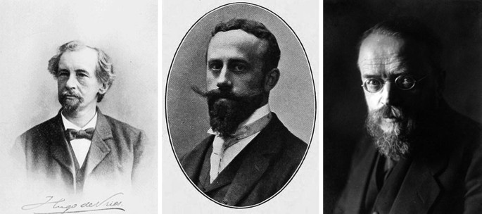

- Hugo de Vries (Dutch botanist)
- Erich Tschermak von Seysenegg (Austrian graduate student)
- Carl Erich Correns (German botanist)

## Battle between Biometricians and the Mendelians

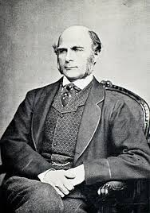

- Galton’s book Natural Inheritance (1889) served as the inspiration for Karl Pearson, W.F.R. Weldon and William Bateson

## Battle between Biometricians and the Mendelians

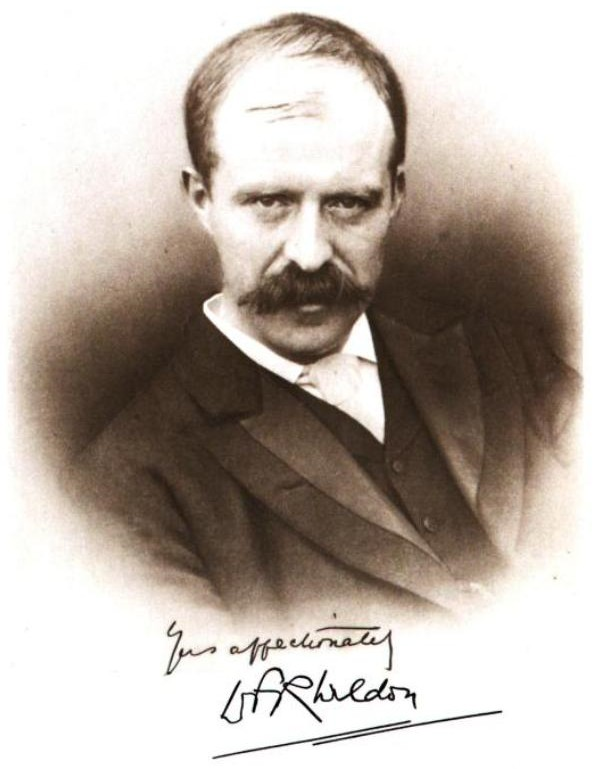

- Pearson and Weldon were interested in **continuously varying** characters and the application of statistical techniques to their study

## Battle between Biometricians and the Mendelians

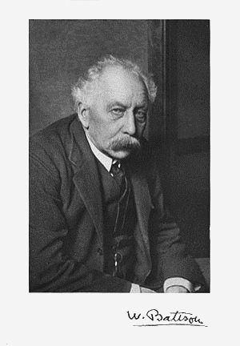

- In contrast, Bateson had published a book on **discontinuously varying** traits so he was in a position to understand and embrace Mendel’s principles of inheritance when they were rediscovered in 1900 (Gillham 2015).
- Mendelian theory finally won out

## Ronald A. Fisher research

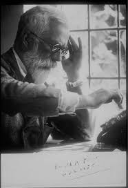

- Extended the use of Student’s t test (developed the theory of significance)
- Provided the correct interpretation of Pearson’s Chi-square
- Variance and Analysis of Variance (ANOVA) 1918
- The design of experiments (Blocking, Replication and Randomizartion - ways of increase reliability)

# Quantitative genetics

## Quantitative genetics

**Basic model**

$$P = G + E$$

**Gene action**

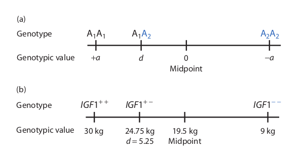

Source: Filipe Ferrão

## Quantitative genetics

- How do gene frequencies affect the mean of a trait in a population?

**Mean Genotypic Value in a Population**

| Genotypes | Freq | Genotypic Value | Freq × Value |
| --- | --- | --- | --- |
| A₁A₁ | $p^2$ | $+a$ | $p^2a$ |
| A₁A₂ | $2pq$ | $d$ | $2pqd$ |
| A₂A₂ | $q^2$ | $-a$ | $-q^2a$ |

# Experimental Design

## Main principles of experimental design

- Replication
- Randomization

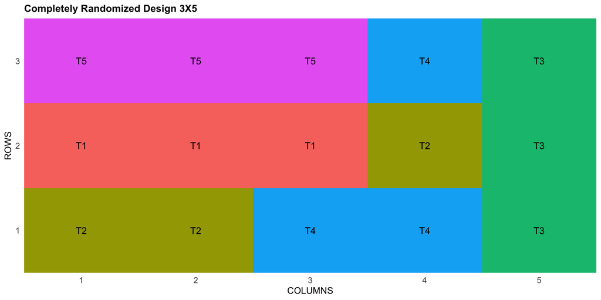

## Main principles of experimental design

- Replication
- Randomization
- **Local control**

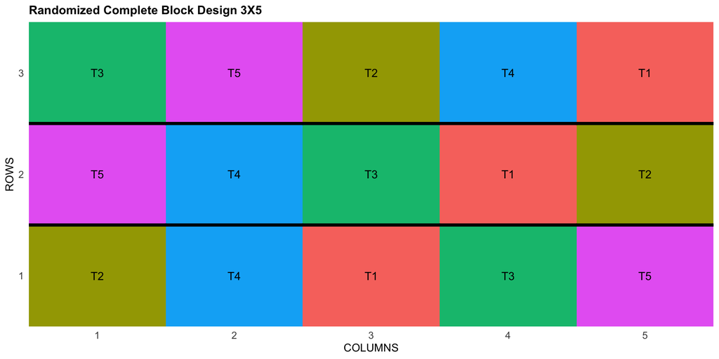

## Square lattice

- Many test genotypes to evaluate in RCBD
- **k** treatments by **k** blocks
- (9treat/k3/rep3)

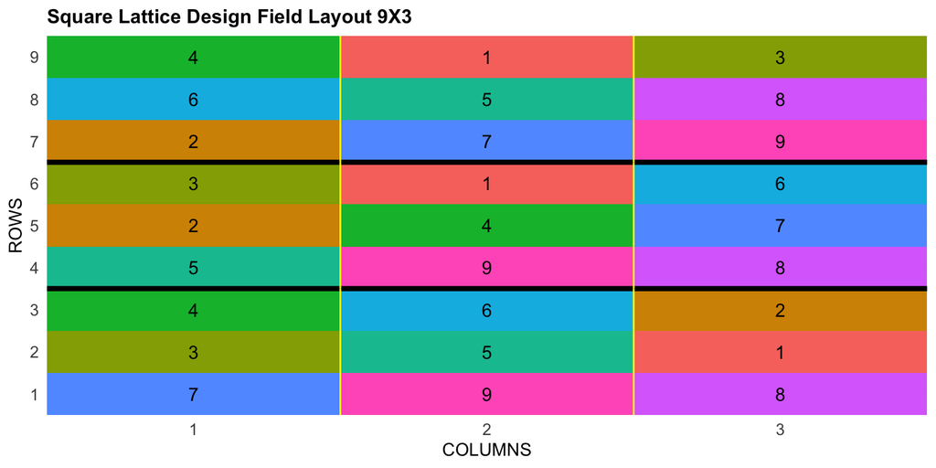

```
  PLOT REP IBLOCK TREATMENT
1 1001   1      1       G-7
2 1002   1      1       G-3
3 1003   1      1       G-4
```

## Augmented randomized complete block design

- Trials with few seeds available
- Large number of treatments
- (30gen/3check/k6)

```
  PLOT ROW COLUMN CHECKS BLOCK ENTRY
1 1001   1      1      1     1     3
2 1002   1      2      1     1     2
3 1003   1      3      0     1    23
```

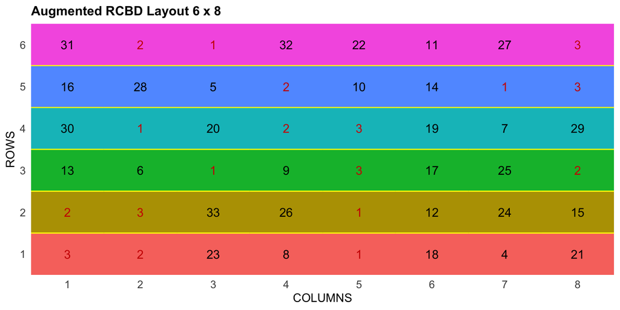

# The basic principles of experimental agriculture

## Basic principles

**Repetição**

Princípio que consiste em repetir mais de uma vez os tratamentos em diferentes unidades experimentais

**Casualização**

Consiste em atribuir de forma aleatória os tratamentos às unidades experimentais

**Controle Local**

Visa construir blocos em um experimento quando as unidades experimentais estiverem dispostas em condições ambientais heterogêneas

# Anova Assumptions

## Análise de variância

**ANOVA**

Ronald Fisher introduziu o termo variância e propôs a sua análise formal em 1918 na revista *theoretical population genetics* com o artigo *The Correlation Between Relatives on the Supposition of Mendelian Inheritance*.

**Definição**

É um método para testar a igualdade de três ou mais médias populacionais baseado na análise das variâncias amostrais

Os dados amostrais são separados em grupos segundo característica (fator).

## Anova Assumptions

**Aditividade**

Condição imposta pelo modelo onde os diversos efeitos se somam.

**Normalidade dos erros**

Os erros devem ser normalmente distribuídos

**Homogeneidade de variâncias**

Assume que os erros possuem a mesma variância.

**Independência dos erros**

A probabilidade do erro de uma observação qualquer assumir um dado valor não deve depender dos valores dos outros erros, o que define a independência deles.

## ANOVA

**Lógica da ANOVA**

Pela lógica da ANOVA o pesquisador compara a variação acidental, ou seja, aquela devida ao acaso, com a variação devido aos tratamentos.

## SQTotal

Pelo procedimento da análise de variância pode se estimar a soma de quadrados totais e decompô-la nos seus vários componentes, permitindo concluir sobre as causas ou fatores de variação.

$$SQ_{Total}= \sum_{ij}Y_{ij}^2- C$$

onde $\sum_{ij}Y_{ij}^2$ é o somatório de Yij ao quadrado e C é um fator de correção

## Estimação dos componentes de Variância

**Quadrado médio**

Os quadrados médios são obtidos dividindo-se as Soma de quadrados pelos graus de liberdade (GL) das respectivas fontes de variação.

## Esperança matemática

A esperança corresponde ao valor médio esperado de um quadrado médio, caso o experimento fosse repetido infinitas vezes.

$$E(QM_T)= \sigma_e^2 + r\sigma_t^2$$

A razão entre QMT/QME fornece o valor de F para se quantificar o componente $\sigma_t^2$

# Statistical models of experimental designs

## Statistical model DIC

**Delineamento Inteiramente Casualizado (DIC)**

$$Y_{ij} = \mu + t_i + e_{ij}$$

$Y_{ij}$ é o valor relativo a observação $ij$

$\mu$ é a média geral do experimento

$t_i$ é o efeito do tratamento $i$

$e_{ij}$ é o erro aleatório

## Statistical model (DIC)

**Hipóteses**

**Hipótese Nula** $H_0$: $\mu_1 = \mu_2 = \mu_i$

**Hipótese Alternativa** $H_1$: $\mu_1 \neq \mu_2 \neq \mu_i$

## Statistical model DBC

**Delineamento em Blocos Casualizados (DBC)**

$$y_{ij}= \mu + t_i + b_j + e_{ij}$$

$Y_{ij}$ é o valor relativo a observação $ij$

$\mu$ é a média geral do experimento

$t_i$ é o efeito do tratamento $i$

$b_j$ é o efeito do bloco $j$

$e_{ij}$ é o erro aleatório

## Statistical model (DBC)

**Hipóteses**

**Hipótese Nula** $H_0$: $\mu_1 = \mu_2 = \mu_i$

**Hipótese Alternativa** $H_1$: $\mu_1 \neq \mu_2 \neq \mu_i$

# Genes software

## Genes Software

[Instalação](https://youtu.be/VIWsEMkQTyE?si=ZUuiKvYkNzhGb2v-)

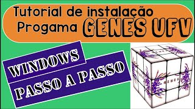

## History

[figure not shown]

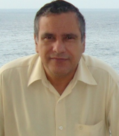

- 1987 - Primeiras Rotinas DOS
- 1990 - Proc. biométricos  
  (3,1 Mbytes - 9 disquetes de 5 1/4 )
- 1993 - Gqmol
- 2001 - Windows 4Mb
- 2013 - Integração com o Software R
- 2023 - Desenvolvimento de novas funções (Cruz 2013)

## Applications

[figure not shown]

Figure 1: Genes software architecture diagram

## Software Genes online

[Genes online](https://arquivo.ufv.br/genetica/WebSite1/Default.aspx)

[figure not shown]

## Suporte para o GENES

Tutoriais e material de apoio podem ser consultado na página Genes News no facebook.

[Facebook : Genes News](https://www.facebook.com/GenesNews)

[figure not shown]

## Delineamento Inteiramente Casualizado

- Experimentos conduzidos sobre condições controladas e homogêneas
- Ex: Ramalho, Ferreira, and Oliveira (2012) - Absorção de água por grãos de feijão

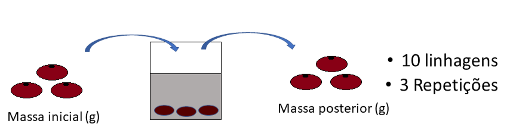

## Delineamento Inteiramente Casualizado

- 10 linhagens e 3 repetições

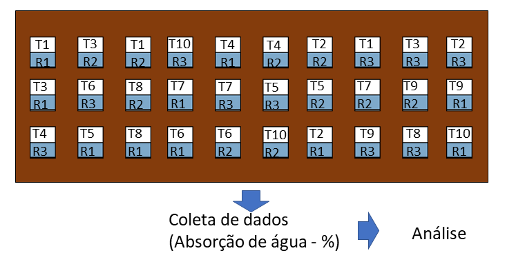

## Delineamento em Blocos Casualizados

- 9 tratamentos e 2 repetições

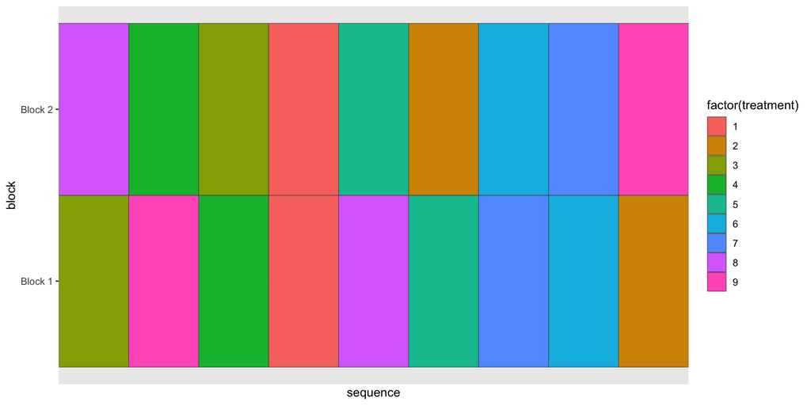

## Delineamento em Látice Simples

- 9 tratamentos e 2 repetições

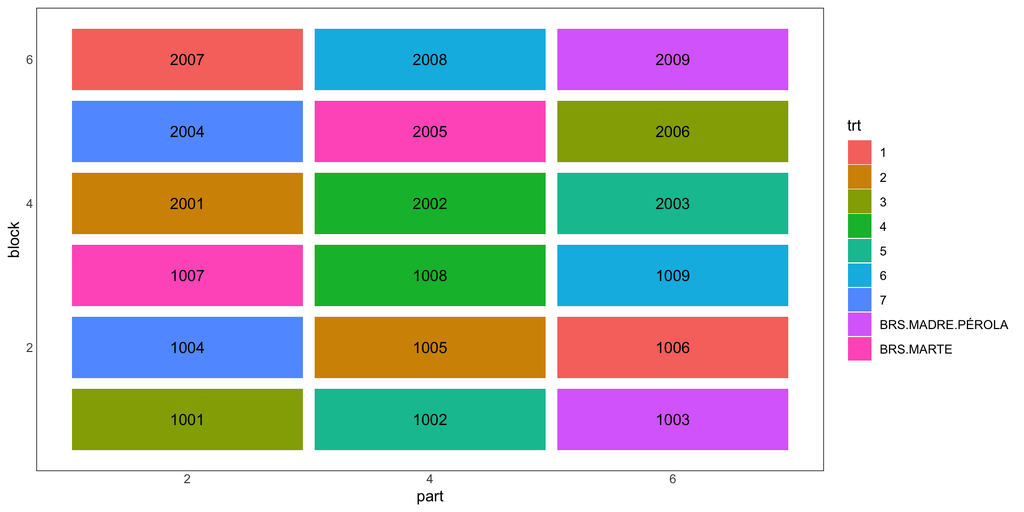

## Delineamento em Blocos Aumentados

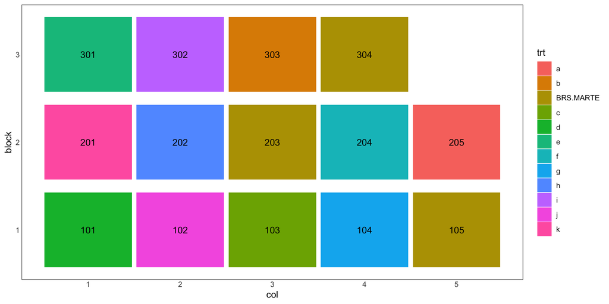

## Planilha de experimentos

[figure not shown]

- Antes de realizar o experimeto (casualização, planejamento)

## Análise de Variância

[figure not shown]

- Depois de realizar o experimento, coletar e analisar os dados.

## Teste de comparação de médias (Dunnet)

- Teste de comparação de médias com um controle (testemunha)
- H0: controle e o tratamento possuem médias iguais.

$$DMS_{Dunnet} = d \propto (k,Gl_{Resíduo}) \frac{\sqrt{2xQMR}}{r}$$

## Bibliography

Cruz, Cosme Damião. 2013. “GENES - a Software Package for Analysis in Experimental Statistics and Quantitative Genetics.” *Acta Scientiarum. Agronomy* 35: 271–76. https://doi.org/10.4025/actasciagron.v35i3.21251.

Gillham, Nicholas W. 2015. “The Battle Between the Biometricians and the Mendelians: How Sir Francis Galton’s Work Caused His Disciples to Reach Conflicting Conclusions about the Hereditary Mechanism.” *Science & Education* 24 (January): 61–75. https://doi.org/10.1007/s11191-013-9642-1.

Ramalho, Magno Antonio Patto, Daniel Furtado Ferreira, and Antonio Carlos de Oliveira. 2012. *Experimentação Em Genética e Melhoramento de Plantas*. 3rd ed. Lavras, MG: Editora UFLA.